# Effect of Loan Characteristics on Borrower's APR

## by (Selasi Ayittah Randy)

## Investigation Overview

> I want to investigate the characteristics of loans that could be used to predict borrower's APR The main interest was on the original loan, borrower rating , loan term and stated monthly income

## Dataset Overview

> The dataset comprises of several atttributes of 113,937 loans by borrowers. The attributes included original loan, borrower rating , loan term and stated monthly income and manay maore.

### Distribution of the LoanOriginalAmount

The distribution of the Loan Original Amount is right skewed with most borrowers given amount less than 20k

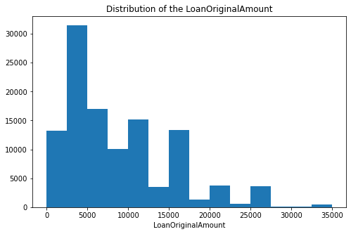

```python
#Distribution of the Loan Original Amount
binsize = 2500
bins = np.arange(0, loan_sub['LoanOriginalAmount'].max()+binsize, binsize)

plt.figure(figsize=[8, 5])
plt.hist(data = loan_sub, x = 'LoanOriginalAmount', bins = bins)
plt.xlabel('LoanOriginalAmount')
plt.title('Distribution of the LoanOriginalAmount')
plt.show()
```

### The distribution of the Borrower APR

The distribution of the APR is multimodal with several peak center at 0.1, 0.2, 0.3. Very few loans have APR greater than 0.43

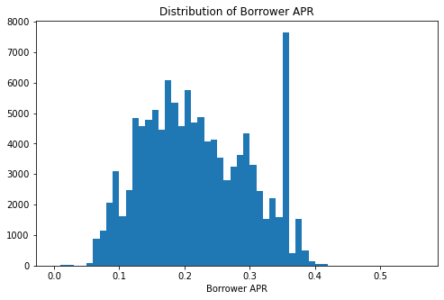

```python
bins = np.arange(0, loan_sub.BorrowerAPR.max()+0.05, 0.01)
plt.figure(figsize=[8, 5])
plt.hist(data = loan_sub, x = 'BorrowerAPR', bins = bins);
plt.xlabel('Borrower APR');
plt.title('Distribution of Borrower APR');
```

### Distrirbution of Original Loan Amount

This distribution is multimodal with several peak at 10k,15k,20k and many more Most of the loans are multiples of 1k

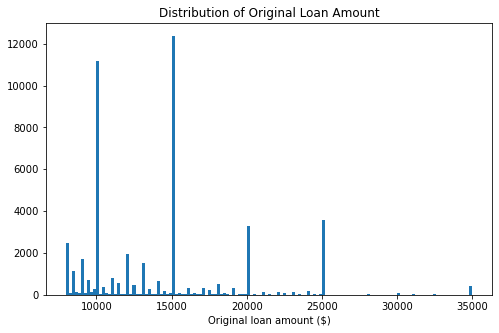

```python
bins = np.arange(8000, loan_sub.LoanOriginalAmount.max()+200, 200)
plt.figure(figsize=[8, 5])
plt.hist(data = loan_sub, x = 'LoanOriginalAmount', bins = bins);
plt.xlabel('Original loan amount ($)');
plt.title('Distribution of Original Loan Amount');
```

### Borrower APR vs. Loan Amount

The borrowe APR decreases with increase of loan amount in general.

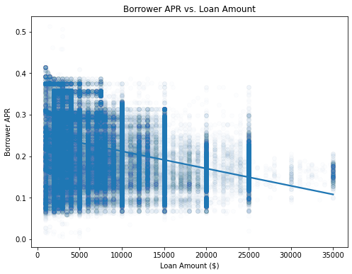

```python
plt.figure(figsize = [8, 6])
sb.regplot(data = loan_sub, x = 'LoanOriginalAmount', y = 'BorrowerAPR', scatter_kws={'alpha':0.01});
plt.xlabel('Loan Amount ($)')
plt.ylabel('Borrower APR')
plt.title('Borrower APR vs. Loan Amount');
```

### Borrower APR vs. Prosper Rating

Prosper rating has a great effect on borrower APR. Borrowers with best ratings have low APR.

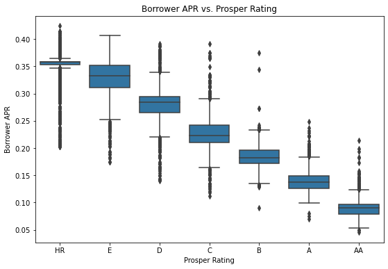

```python
plt.figure(figsize=[9,6])
default_color = sb.color_palette()[0]
sb.boxplot(data=loan_sub, x='ProsperRating (Alpha)', y='BorrowerAPR', color=default_color)
plt.xlabel('Prosper Rating')
plt.ylabel('Borrower APR')
plt.title('Borrower APR vs. Prosper Rating');
```

### Prosper Rating Effect on Relationship between APR and Loan Amount

The loan amount increases with better rating. The borrower APR decreases with better rating. The relationship between borrower APR and loan amount turns from negative to slightly positive when the Prosper ratings are increased from HR to A or better

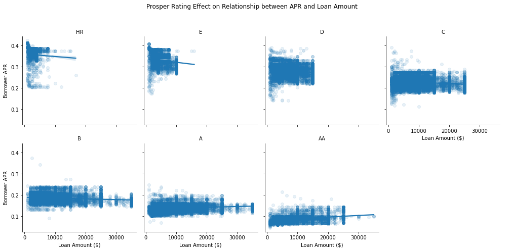

```python
g=sb.FacetGrid(data=loan_sub,col='ProsperRating (Alpha)', height=3.5, col_wrap=4)
g.map(sb.regplot, 'LoanOriginalAmount', 'BorrowerAPR', x_jitter=0.04, scatter_kws={'alpha':0.1});
g.set_titles('{col_name}')
g.add_legend();
g.set_xlabels('Loan Amount ($)')
g.set_ylabels('Borrower APR')
plt.suptitle('Prosper Rating Effect on Relationship between APR and Loan Amount');
plt.subplots_adjust(top=0.85)
```

```python
! jupyter nbconvert slide_deck.ipynb  --to slides --post serve --no-input --no-prompt
```

[output not shown]

```python
!jupyter nbconvert slide_deck.ipynb --to slides --post serve --template output_toggle
```